# 6월 11일 NLP 과제

황 성 윤

2019 6 11

# 서울시 응답소 2015년 데이터에서 중요한 키워드를 찾아 워드 클라우드를 만드시오.

# 단, 다음의 조건을 충족시켜야 함.

# 1. 제거해야할 단어를 저장한 gsub 파일을 만들 것

# 2. stringr 패키지를 사용할 것

# 3. R Markdown 보고서를 만들어서 제출할 것

## 라이브러리 할당 및 해당 패키지 설치

```r
setwd("D:/Workplace/R_Data_Analysis/part2/stage1_Wordcloud/6월 11일 NLP 분석 과제")
library(rJava)
library(KoNLP)
library(wordcloud)
library(RColorBrewer)
library(stringr)
useSejongDic()
```

```
## Backup was just finished!
## 370957 words dictionary was built.
```

## 데이터 불러들이기 및 명사 추출

2015년 서울시 응답소 데이터에 대한 NLP 분석을 통해 2015년 한해동안 서울시 내의 주요 화젯거리를 알아본다. 이를 위해 우선 2015년 1월부터 12월까지의 서울시 응답소 데이터를 처리하여 2015년 한해동안의 서울시민들의 생각이 담긴 명사들을 추출한다.

```r
seoul01 <- readLines("data/응답소_2015_01.txt")
seoul02 <- readLines("data/응답소_2015_02.txt")
seoul03 <- readLines("data/응답소_2015_03.txt")
seoul04 <- readLines("data/응답소_2015_04.txt")
seoul05 <- readLines("data/응답소_2015_05.txt")
seoul06 <- readLines("data/응답소_2015_06.txt")
seoul07 <- readLines("data/응답소_2015_07.txt")
seoul08 <- readLines("data/응답소_2015_08.txt")
seoul09 <- readLines("data/응답소_2015_09.txt")
seoul10 <- readLines("data/응답소_2015_10.txt")
seoul11 <- readLines("data/응답소_2015_11.txt")
seoul12 <- readLines("data/응답소_2015_12.txt")

seoul01 <- sapply(seoul01,extractNoun,USE.NAMES=F)
seoul01 <- unlist(seoul01)
seoul02 <- sapply(seoul02,extractNoun,USE.NAMES=F)
seoul02 <- unlist(seoul02)
seoul03 <- sapply(seoul03,extractNoun,USE.NAMES=F)
seoul03 <- unlist(seoul03)
seoul04 <- sapply(seoul04,extractNoun,USE.NAMES=F)
seoul04 <- unlist(seoul04)
seoul05 <- sapply(seoul05,extractNoun,USE.NAMES=F)
seoul05 <- unlist(seoul05)
seoul06 <- sapply(seoul06,extractNoun,USE.NAMES=F)
seoul06 <- unlist(seoul06)
seoul07 <- sapply(seoul07,extractNoun,USE.NAMES=F)
seoul07 <- unlist(seoul07)
seoul08 <- sapply(seoul08,extractNoun,USE.NAMES=F)
seoul08 <- unlist(seoul08)
seoul09 <- sapply(seoul09,extractNoun,USE.NAMES=F)
seoul09 <- unlist(seoul09)
seoul10 <- sapply(seoul10,extractNoun,USE.NAMES=F)
seoul10 <- unlist(seoul10)
seoul11 <- sapply(seoul11,extractNoun,USE.NAMES=F)
seoul11 <- unlist(seoul11)
seoul12 <- sapply(seoul12,extractNoun,USE.NAMES=F)
seoul12 <- unlist(seoul12)

seoul_2015 <- c(seoul01,seoul02,seoul03,seoul04,seoul05,seoul06,
                seoul07,seoul08,seoul09,seoul10,seoul11,seoul12)
```

## 데이터 분석

### 데이터 처리

분석에 방해되는 문자열 제거

```r
length(seoul_2015)
```

```
## [1] 169180
```

```r
head(seoul_2015,30)
```

```
##  [1] "제목"               "안녕"               "시장님공개일"
##  [4] "2015-01-31상담내용" "Q"                  "상담내용"
##  [7] "저"                 "성북구"             "애완견"
## [10] "한마"               "리"                 "주민"
## [13] "다름이아니고"       "애견"               "놀이터"
## [16] "관련"               "한"                 "현재"
## [19] "서울시에서"         "운영"               "무료"
## [22] "애견"               "놀이터"             "어린이대공원"
## [25] "상암동"             "하늘"               "공원"
## [28] "있는걸로"           "애완견"             "산책을할때"
```

```r
seoul_2015 <- str_replace_all(seoul_2015,"[^[:alpha:]]","") # 한글, 영어 이외는 제거
seoul_2015 <- str_replace_all(seoul_2015,"[A-z]","") # 모든 영문자 제거
seoul_2015 <- str_replace_all(seoul_2015,"\\s","") # 공백 제거
seoul_2015 <- str_replace_all(seoul_2015,"\\d","") # 숫자 제거
```

데이터를 살펴본 결과, 1글자 이하, 4글자 이상의 명사는 제외시켜도 이상없다고 판단됨. 이에 따라 글자수가 2글자 이상 3글자 이하의 명사들만 남기고 제거하기로 함.

```r
seoul_2015 <- Filter(function(x) {nchar(x)>=2 & nchar(x)<=3}, seoul_2015)
```

### 필요없는 문자열 제거

```r
length(seoul_2015)
```

```
## [1] 103152
```

```r
txt <- readLines("data/seoul_gsub.txt")
for (i in 1:length(txt)) {
  seoul_2015 <- gsub((txt[i]),"",seoul_2015)
}
write(unlist(seoul_2015),"data/seoul_2015_1.txt")
seoul_2015 <- read.table("data/seoul_2015_1.txt")
```

### Wordcloud를 통한 NLP 분석

데이터의 크기가 방대한만큼 빈도수가 너무 적은 명사는 제외하는 것이 타당하다고 판단됨. 이에 따라 빈도수가 1인 명사는 분석에서 제외시킴.

```r
nrow(seoul_2015)
```

```
## [1] 96709
```

```r
wordcount <- table(seoul_2015)
head(sort(wordcount,decreasing=T),30)
```

```
## seoul_2015
##   시장   생각 동성애   시민   사람   주민   축제   답변   문제   민원
##   1115    974    696    647    643    530    514    479    462    443
##   공사   우리 아이들   시간   설치 어린이   저희   관리   버스   국민
##    435    428    425    419    400    375    347    343    343    341
##   요청   이용   반대   내용 공무원   구청   서울   상황   시설   경우
##    329    316    315    307    303    298    286    279    277    264
```

```r
wordcount <- wordcount[wordcount > 1] # 빈도수가 1인 명사 제외
```

분석결과에 대한 wordcloud plot

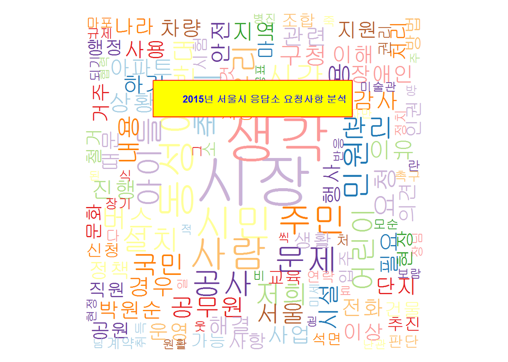

```r
palete <- brewer.pal(12,"Paired")
par(oma=rep(0,4))
wordcloud(names(wordcount),freq=wordcount,scale=c(5,1),rot.per=0.25,min.freq=2,
          random.order=F,random.color=T,colors=palete)
legend(0.2,0.8,"2015년 서울시 응답소 요청사항 분석",cex=0.8,fill=NA,border=NA,bg="yellow",
       text.col="blue",text.font=2,box.col="red")
```

분석결과, 시장, 생각, 시민, 사람, 주민 등의 단어의 빈도가 높게 나타났다. 2015년 한해동안 서울시민들이 의사소통이 제대로 되는 사회를 희망했던 것으로 풀이된다. 또한, 공무원, 아이들, 어린이 등의 단어도 빈도가 있는 것으로 보아 어린이들이 좀 더 안전하게 살아갈 수 있는 사회에 대한 서울시민들의 바람을 엿볼 수 있다.